# Assignment 2

Author

Boubacar Bah

## Instructions

Complete the following exercises **using only the tidyverse packages** (e.g., `dplyr`, `tidyr`, `ggplot2`, `readr`, `stringr`, `forcats`, `lubridate`, `purrr`, etc.)

**Important:** This assignment is intended to assess your proficiency with the **tidyverse**. Solutions that use **base R** or **packages outside the tidyverse** to solve the problems will **not receive credit** unless explicitly permitted in the question.

1. Load the necessary **tidyverse** libraries.

```r
library(dplyr)
library(tidyverse)
```

2. Answer each question in a separate R code chunk.
3. Provide a detailed explanation of your approach for each solution.
4. Render your R Markdown document to an HTML file.
5. Submit the rendered HTML file to Canvas.

# Question:

- Task 1: Read data using a relative path

```r
college_data1 <- read_csv("/home/boubacar/Documents/Data-413/Homework/collegedata.csv")
```

```r
Example:
college_data <- read_csv("../data/collegedata.csv")
```

- Task 2:Determine rows and columns

```r
glimpse(college_data1)
```

```
Rows: 7,175
Columns: 12
$ UNITID         <dbl> 100654, 100663, 100690, 100706, 100724, 100751, 100760,…
$ OPEID          <dbl> 100200, 105200, 2503400, 105500, 100500, 105100, 100700…
$ MN_EARN_WNE_P6 <chr> "27800", "37600", "39400", "41300", "23500", "38500", "…
$ INSTNM         <chr> "Alabama A & M University", "University of Alabama at B…
$ SAT_AVG        <dbl> 849, 1125, NA, 1257, 825, 1202, NA, NA, 1009, 1217, 115…
$ ADM_RATE       <dbl> 0.8738, 0.5814, NA, 0.7628, 0.4590, 0.5259, NA, NA, 0.7…
$ UGDS           <dbl> 4616, 12047, 293, 6346, 4704, 31663, 1492, 2888, 4171, …
$ COSTT4_A       <dbl> 22667, 22684, 13380, 22059, 19242, 28422, 13868, NA, 19…
$ AVGFACSAL      <dbl> 7028, 10517, 3857, 9463, 7952, 9802, 5960, 8367, 7251, …
$ GRAD_DEBT_MDN  <chr> "32750", "21833", "22890", "22647", "31500", "23290", "…
$ AGE_ENTRY      <chr> "20.28374137", "23.60797466", "33.6722973", "22.7279196…
$ ICLEVEL        <dbl> 1, 1, 1, 1, 1, 1, 2, 1, 1, 1, 1, 2, 1, 1, 2, 2, 1, 2, 3…
```

rows: 7175 and columns 12.

- Task 3: Use tidyverse to select INSTNM, SAT_AVG, and ADM_RATE

```r
college_data1 %>% select(
  "INSTNM",
  "SAT_AVG",
  "ADM_RATE",
)
```

```
# A tibble: 7,175 × 3
   INSTNM                              SAT_AVG ADM_RATE
   <chr>                                 <dbl>    <dbl>
 1 Alabama A & M University                849    0.874
 2 University of Alabama at Birmingham    1125    0.581
 3 Amridge University                       NA   NA
 4 University of Alabama in Huntsville    1257    0.763
 5 Alabama State University                825    0.459
 6 The University of Alabama              1202    0.526
 7 Central Alabama Community College        NA   NA
 8 Athens State University                  NA   NA
 9 Auburn University at Montgomery        1009    0.766
10 Auburn University                      1217    0.805
# ℹ 7,165 more rows
```

- Task 4: Create a scatterplot for SAT_AVG and ADM_RATE (Remove NA)

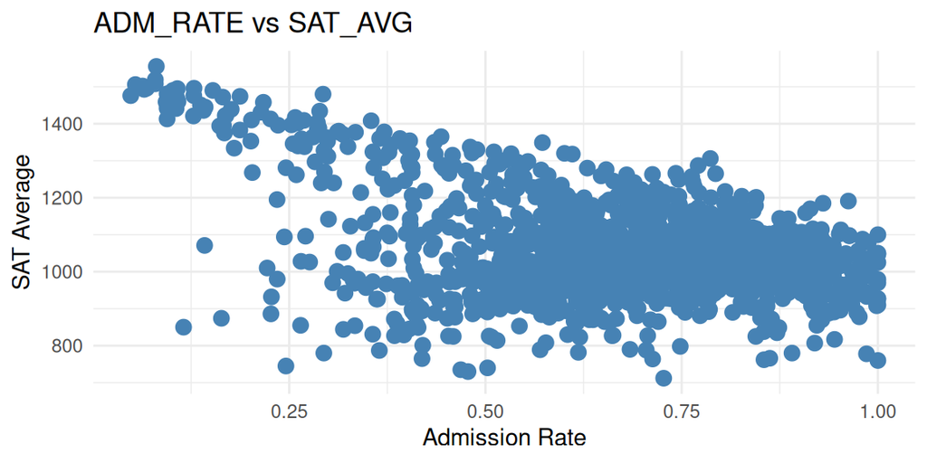

```r
college_data1 <- college_data1 %>%
  filter(SAT_AVG != "NA", ADM_RATE != "NA")

college_data1 <- college_data1 %>% select(
  SAT_AVG, ADM_RATE
)

ggplot(college_data1, aes(x = ADM_RATE, y = SAT_AVG)) +
  geom_point(color = "steelblue", size = 3) +
  labs(
    title = "ADM_RATE vs SAT_AVG",
    x = "Admission Rate",
    y = "SAT Average"
  ) +
  theme_minimal()
```

## Submission

- After completing **each question**, save your Quarto file, render it, then **stage and commit** your changes.
- Each commit should:
  - Represent **one logical change**.
  - Have a **short, descriptive** commit message.
  - Be written in the **present tense** (imperative mood).

  **Examples:**

  **Bad:** `Fix bug in the project` *Too vague—it does not explain which bug was fixed.*

  **Bad:** `Fixed crash on login screen when password is empty` *Uses the past tense.*

  **Good:** `Fix crash on login screen when password is empty`
- Include well-commented code and clear explanations for each solution.
- Make **at least one meaningful commit per question/part** (a minimum of **4 meaningful commits**).
- **Push your work to your** GitHub**. ane post the link on the text bar of the Canvas assignment.
- Assignments that are **not pushed to GitHub** will receive **no more than 60% of the available points**.
- Submit the rendered HTML file to **Canvas**. Assignments that are **not submitted to Canvas** will also receive **no more than 60% of the available points**.
- If you forget to submit your work to **GitHub** or **Canvas**, you have **up to three (3) days** after the due date to correct the submission. A **10% late penalty** will be applied to the assignment. **After three days, no submissions or corrections will be accepted.**
- **No corrections, re-submissions, or missing submissions will be accepted after the assignment has been graded**, including forgotten GitHub or Canvas submissions.

**Good luck!**